# Projet stats sur la culture cinématographique

## Imports

```python
import pandas as pd
import numpy as np
pd.options.display.max_columns = 70
```

```python
import seaborn as sns
import matplotlib
import matplotlib.pyplot as plt
%matplotlib inline
sns.set_style('darkgrid')
```

```python
from plotly import __version__
from plotly.offline import download_plotlyjs, init_notebook_mode, plot, iplot
import plotly.tools as tls
import plotly.graph_objs as go
import plotly.plotly as py

print(__version__) # requires version >= 1.9.0
```

```
3.4.0
```

```python
import cufflinks as cf
init_notebook_mode(connected=True)
cf.go_offline()
```

```python
from scipy.stats import ttest_ind
from scipy.stats import ttest_rel
from scipy.stats import shapiro
from scipy.stats import f_oneway
from scipy.stats import chisquare
import statsmodels.api as sm
import statsmodels.formula.api as smf
import statsmodels.stats as sms
from statsmodels.formula.api import ols
```

```python
matplotlib.rc('figure', titlesize='24')
matplotlib.rc('legend', fontsize='medium')
matplotlib.rc('axes', titlesize='22', titleweight='bold')
matplotlib.rc('xtick', labelsize='18')
matplotlib.rc('ytick', labelsize='18')
matplotlib.rc('axes', labelsize='20')
matplotlib.rc('font', size='18')
```

```python
dataset = pd.read_csv("resultsOfSurvey.csv", sep= ",")
```

## Visualisation des données

```python
dataset.head()
```

|  | id | Completed | 003 | 0002 | 0004 | 0005 | 0001 | 0001.1 | 0001.2 | 0001.3 | 0001.4 | 0001.5 | 0002.1 | 0001.6 | 0002.2 | 0001.7 | 0002.3 | 0001.8 | 0002.4 | 0001.9 | 0002.5 | 0001.10 | 0001.11 | 0001.12 | 0002.6 | 0001.13 | 0002.7 | 0001.14 | 0002.8 | … |
| --- | --- | --- | --- | --- | --- | --- | --- | --- | --- | --- | --- | --- | --- | --- | --- | --- | --- | --- | --- | --- | --- | --- | --- | --- | --- | --- | --- | --- | --- | --- |
| 0 | 4 | Y | 21.0 | Homme | France | Oui | Musique | Yes | Star Wars | No | NaN | Yes | Livre de la jungle | Yes | Titanic | Yes | Star wars | Yes | Titanic | Yes | Roo lion | Yes | Seigneur des anneaux | Yes | Terminator | Yes | LOTR | NaN | Plus de 5 fois | … |
| 1 | 5 | Y | 19.0 | Homme | France | Oui | Musique | Yes | Star Wars épisode V : L'Empire Contre-Attaque | Yes | Terminator | Yes | Le Roi Lion | Yes | Titanic | Yes | Star Wars | Yes | Titanic | Yes | Le Roi Lion | Yes | Le seigneur des anneaux | Yes | Terminator | Yes | Le seigneur des anneaux | NaN | Plus de 5 fois | … |
| 2 | 6 | Y | 21.0 | Homme | France | Oui | Musique | Yes | Star Wars V : L'empire contre-attaque | Yes | Terminator | Yes | Le Roi Lion | Yes | Titanic | Yes | Star Wars | Yes | Titanic | Yes | Le Roi Lion | Yes | Le Seigneur des Anneaux | Yes | La pub pour After Eight :) | Yes | Le Seigneur des Anneaux | NaN | Plus de 5 fois | … |
| 3 | 7 | Y | 21.0 | Homme | France | Oui | Musique | Yes | Star Wars episode 5 | No | NaN | No | NaN | Yes | Le roi lion | Yes | Star wars | Yes | Titanic | Yes | Le roi lion | Yes | Le seigneur des anneaux | No | NaN | Yes | Le seigneur des anneaux- la communauté de l’an... | NaN | Plus de 5 fois | … |
| 4 | 8 | Y | 21.0 | Homme | France | Oui | Musique | Yes | star wars | Yes | terminator | Yes | le roi lion | Yes | titanic | Yes | star wars | Yes | titanic | Yes | le roi lion | Yes | le seigneur des anneaux | Yes | terminator | Yes | le seigneur des anneaux | NaN | 1 fois | … |

Le fichier ne contient que des réponses complètes, nous pouvont donc drop la colonne "Completed" qui est tout le temps égale à Y  
Les colonnes 0001.14, 0004.1, 0007, 0010 et 0013 sont hors de propos

```python
dataset.drop("Completed", axis =1, inplace = True)
dataset.drop(["0001.14", "0004.1", "0007", "0010","0013"], axis =1, inplace = True)
```

```python
dataset.columns
```

```
Index(['id', '003', '0002', '0004', '0005', '0001', '0001.1', '0001.2',
       '0001.3', '0001.4', '0001.5', '0002.1', '0001.6', '0002.2', '0001.7',
       '0002.3', '0001.8', '0002.4', '0001.9', '0002.5', '0001.10', '0001.11',
       '0001.12', '0002.6', '0001.13', '0002.7', '0002.8', '0003', '0005.1',
       '0006', '0008', '0009', '0011', '0012', '0014', '0015',
       '0007 [Répliques]', '0007 [Musique]', '0007 [Qualité de l'histoire]',
       '0007 [Revoir un film plusieurs fois sans se lasser]',
       '0007 [L'avoir vu enfant]', '0007 [Porteur d'émotion]'],
      dtype='object')
```

```python
NewColName = ["id","age","sexe","nationalite","etudiant_IMT","musique/Replique",
              "sw_rep_1", "sw_rep_2","ter_mus_1","ter_mus_2","rl_rep_1","rl_rep_2",
             "tit_mus_1","tit_mus_2","sw_mus_1","sw_mus_2","tit_rep_1","tit_rep_2",
             "rl_mus_1","rl_mus_2","lotr_mus_1","lotr_mus_2","ter_rep_1","ter_rep_2",
             "lotr_rep_1","lotr_rep_2","sw_nbr_vis", "sw_age_vis","rl_nbr_vis","rl_age_vis",
             "tit_nbr_vis","tit_age_vis","lotr_nbr_vis","lotr_age_vis","ter_nbr_vis","ter_age_vis",
             "répliques","musique","qualite_Histoire","revoir_film","avoir_vu_enfant","porteur_emotion"]
```

Ici :

- 1 --> Est ce que vous connaissez la réplique /musique
- 2 --> Le nom du film associé
- rep --> Réplique
- mus --> Musique
- nbr_vis --> Nombre de visionage

Modification des colonnes

```python
dataset.set_axis(NewColName, axis = 1, inplace= True)
```

```python
dataset.head()
```

|  | id | age | sexe | nationalite | etudiant_IMT | musique/Replique | sw_rep_1 | sw_rep_2 | ter_mus_1 | ter_mus_2 | rl_rep_1 | rl_rep_2 | tit_mus_1 | tit_mus_2 | sw_mus_1 | sw_mus_2 | tit_rep_1 | tit_rep_2 | rl_mus_1 | rl_mus_2 | lotr_mus_1 | lotr_mus_2 | ter_rep_1 | ter_rep_2 | lotr_rep_1 | lotr_rep_2 | sw_nbr_vis | sw_age_vis | rl_nbr_vis | … |
| --- | --- | --- | --- | --- | --- | --- | --- | --- | --- | --- | --- | --- | --- | --- | --- | --- | --- | --- | --- | --- | --- | --- | --- | --- | --- | --- | --- | --- | --- | --- |
| 0 | 4 | 21.0 | Homme | France | Oui | Musique | Yes | Star Wars | No | NaN | Yes | Livre de la jungle | Yes | Titanic | Yes | Star wars | Yes | Titanic | Yes | Roo lion | Yes | Seigneur des anneaux | Yes | Terminator | Yes | LOTR | Plus de 5 fois | 11-20 years old | 2-5 fois | … |
| 1 | 5 | 19.0 | Homme | France | Oui | Musique | Yes | Star Wars épisode V : L'Empire Contre-Attaque | Yes | Terminator | Yes | Le Roi Lion | Yes | Titanic | Yes | Star Wars | Yes | Titanic | Yes | Le Roi Lion | Yes | Le seigneur des anneaux | Yes | Terminator | Yes | Le seigneur des anneaux | Plus de 5 fois | 0-10 years old | 2-5 fois | … |
| 2 | 6 | 21.0 | Homme | France | Oui | Musique | Yes | Star Wars V : L'empire contre-attaque | Yes | Terminator | Yes | Le Roi Lion | Yes | Titanic | Yes | Star Wars | Yes | Titanic | Yes | Le Roi Lion | Yes | Le Seigneur des Anneaux | Yes | La pub pour After Eight :) | Yes | Le Seigneur des Anneaux | Plus de 5 fois | 0-10 years old | 2-5 fois | … |
| 3 | 7 | 21.0 | Homme | France | Oui | Musique | Yes | Star Wars episode 5 | No | NaN | No | NaN | Yes | Le roi lion | Yes | Star wars | Yes | Titanic | Yes | Le roi lion | Yes | Le seigneur des anneaux | No | NaN | Yes | Le seigneur des anneaux- la communauté de l’an... | Plus de 5 fois | 0-10 years old | Plus de 5 fois | … |
| 4 | 8 | 21.0 | Homme | France | Oui | Musique | Yes | star wars | Yes | terminator | Yes | le roi lion | Yes | titanic | Yes | star wars | Yes | titanic | Yes | le roi lion | Yes | le seigneur des anneaux | Yes | terminator | Yes | le seigneur des anneaux | 1 fois | 11-20 years old | 2-5 fois | … |

## Clean des datas

### Drop des réponses troll

```python
dataset[dataset["id"] == 84]
dataset[dataset["id"] == 16]
```

|  | id | age | sexe | nationalite | etudiant_IMT | musique/Replique | sw_rep_1 | sw_rep_2 | ter_mus_1 | ter_mus_2 | rl_rep_1 | rl_rep_2 | tit_mus_1 | tit_mus_2 | sw_mus_1 | sw_mus_2 | tit_rep_1 | tit_rep_2 | rl_mus_1 | rl_mus_2 | lotr_mus_1 | lotr_mus_2 | ter_rep_1 | ter_rep_2 | lotr_rep_1 | lotr_rep_2 | sw_nbr_vis | sw_age_vis | rl_nbr_vis | … |
| --- | --- | --- | --- | --- | --- | --- | --- | --- | --- | --- | --- | --- | --- | --- | --- | --- | --- | --- | --- | --- | --- | --- | --- | --- | --- | --- | --- | --- | --- | --- |
| 10 | 16 | 56.0 | Femme | Andorre | Non | Musique | No | NaN | Yes | Le monde de Nemo | Yes | Hakuna matata le célèbre manga | Yes | Le seigneur des agneaux | Yes | Star Wars a spécial holiday | Yes | Roger rabbit | No | NaN | No | NaN | Yes | Taken | Yes | Wikipedia | Plus de 5 fois | More than 20 years old | Plus de 5 fois | … |

```python
dataset.drop(dataset[dataset["id"] == 84].index, axis =0, inplace = True)
```

```python
dataset.drop(dataset[dataset["id"] == 16].index, axis =0, inplace = True)
```

### Clean de sw_rep_2

On utilise ces valeurs pour définir si un film est vu ou non

```python
unknown = "unknown"
known = "known"
```

```python
def repplace(df,colname, value):
    for k in value :
        dataset[colname] = dataset[colname].apply(lambda var : known if k in var.lower() else var)

def finalize(df,colname):
    l = dataset[colname].unique()
    l = l[l != known]
    l = l[l != unknown]
    dataset[colname] = dataset[colname].apply(lambda var : unknown if var in (l) else var)
```

```python
dataset["sw_rep_2"].fillna(value = unknown, inplace = True)
```

```python
dataset["sw_rep_2"] = dataset["sw_rep_2"].apply(lambda var : known if 'star wars' in var.lower() else var)
```

```python
dataset["sw_rep_2"].unique()
```

```
array(['known', 'L’Empire contre-attaque ', 'La guerre des étoiles 3',
       'StarWARS', 'unknown', 'le retour du jedi', 'Starwars',
       'Le retour du Jedi', 'star war', "l'empire contre attaque",
       'Le truc avec le jedi', 'Guerre des etoiles', 'Star war',
       'stars war', 'Le royaume des couleurs', 'Stars wars',
       "L'Empire contre attaque", 'Smurf', 'guerre des etoiles',
       'La guerre des étoiles', 'The Empire Strikes Back',
       "Starwars : l'empire contre attaque", 'Le retour du jedi',
       'Stars Wars', "L'empire contre attaque"], dtype=object)
```

```python
repplace(dataset,"sw_rep_2",["empire","jedi","guerre","starwars","stars wars","star war","stars war"])
```

```python
finalize(dataset,"sw_rep_2")
```

```python
dataset["sw_rep_2"].unique()
```

```
array(['known', 'unknown'], dtype=object)
```

## Application de la même procédure pour les autres films

```python
dictt = {"ter_mus_2": ["terminator"] ,
         "rl_mus_2":['roi lion',"roo lion","roi lyon","lion king","le roi loin","prince tigre",'nakouna matata'],
         'sw_mus_2': ["star wars","empire","sw","starwar","star wa","guerre ","stawar","stars wa","starwax","jeudi"],
        'lotr_mus_2': ["seigneur des anneaux","lord of the ring","seigneur","la meilleure","lotr","communauté de l'anneau"," avec les orcs et les nains","hobbit"],
        'tit_mus_2': ["titanic","bateau","tani"],
         "ter_rep_2": ["terminator","termiantor","governator","robot"] ,
         "rl_rep_2":['roi lion',"AKUMANATAT".lower(),"roi lyon","lion king","roi l","akouna mata","matata"],
        'lotr_rep_2':  ["seigneur des anneaux","lord of the ring","seigneur","la meilleure","lotr","communauté de l'anneau"," avec les orcs et les nains","hobbit","GO BACK".lower(),"senior","fellowship"],
        'tit_rep_2': ["titanic","bateau","tani"],
        }
```

```python
for k in dictt :
    dataset[k].fillna(value = unknown, inplace = True)
    repplace(dataset,k,dictt[k])
```

### Clean de ter_mus_2

```python
dataset['ter_mus_2'].unique()
```

```
array(['unknown', 'known', 'Les Visiteurs ', 'me souviens plus',
       'Les Visiteurs', 'Game of Throne', 'Seigneur des années',
       'Seigneur dés anneaux ', 'je sais plus exactement ',
       'Seigneur des anneaux ', 'Predator 2', 'Braveheart',
       'Game of Thrones', 'seigneur des anneaux peut etre',
       'Le seigneur des anneaux ',
       "J'ai entendu cette musique dans la série Hero Corp ! Mais elle est probablement aussi dans un Marvel",
       'Seigneur des anneaux', 'La guerre des étoiles',
       'Pirates des caraïbes', 'Lord of The Ring',
       'Pas sure, Indiana Jones?', 'Pirates des Caraïbes', 'Backdraft',
       'Le seigneur des anneaux', 'Christophe Colomb', 'Game of thrones',
       'seigneur des anneaux', 'game of thrones', 'Je sais plus',
       'Pirates des Caraibes', 'Je ne sais plus', 'Christophe Collomb '],
      dtype=object)
```

```python
finalize(dataset , 'ter_mus_2')
```

```python
dataset['ter_mus_2'].unique()
```

```
array(['unknown', 'known'], dtype=object)
```

### Clean de rl_mus_2

```python
dataset['rl_mus_2'].unique()
```

```
array(['known', 'unknown', 'Le livre de la jungle', 'Avatar',
       "Je m'en rappelle plus ", 'Le Livre de La Jungle', 'Black Panther',
       'Le roi ', 'Invictus', 'tarzen', 'blood diamond', 'Moana',
       "ch'sais plus, un truc sud africain"], dtype=object)
```

```python
finalize(dataset , 'rl_mus_2')
```

```python
dataset['rl_mus_2'].unique()
```

```
array(['known', 'unknown'], dtype=object)
```

### Clean de sw_mus_2

```python
dataset['sw_mus_2'].unique()
```

```
array(['known', 'Pirates des Caraïbes', 'unknown', 'Game of Throne',
       'Captain America '], dtype=object)
```

```python
finalize(dataset , 'sw_mus_2')
```

```python
dataset['sw_mus_2'].unique()
```

```
array(['known', 'unknown'], dtype=object)
```

### Clean de lotr_mus_2

```python
dataset['lotr_mus_2'].unique()
```

```
array(['known', 'unknown', '?', 'Star Trek',
       'Je ne retrouve plus le titre', 'Hunger Games',
       'je saiiiiis plus aaaarf', 'Superman', 'Star Wars ', 'Avengers',
       'Je ne retrouve plus, mais je connais :(', 'Me souviens plus',
       'Merlín', 'Back to the future', 'Robin des Bois',
       'Pirates de Caraïbes ', 'Les Marvel !', 'Pirates des Caraïbes',
       'Retour vers le futur', 'Pirate des caraibes', 'Jurassic Park',
       'Star Wars', 'Braveheart'], dtype=object)
```

```python
finalize(dataset , 'lotr_mus_2')
```

```python
dataset['lotr_mus_2'].unique()
```

```
array(['known', 'unknown'], dtype=object)
```

### Clean de tit_mus_2

```python
dataset["tit_mus_2"].unique()
```

```
array(['known', 'Le roi lion ', 'Le roi lion (je suis pas sûr du tout)',
       '?', 'unknown', 'Je me souviens plus...', '??', 'Le roi lion',
       "Don't remember ", 'la conté des hobbits', 'Pocahontas',
       "ch'sais plus", 'pocahontas'], dtype=object)
```

```python
finalize(dataset , 'tit_mus_2')
```

```python
dataset["tit_mus_2"].unique()
```

```
array(['known', 'unknown'], dtype=object)
```

### Clean de ter_rep_2

```python
dataset["ter_rep_2"].unique()
```

```
array(['known', 'La pub pour After Eight :)', 'unknown', '?', 'Predator',
       'Le seigneur des anneaux ',
       'ABotu 5 Arnold Sch. Films, Total Recall, ...'], dtype=object)
```

```python
finalize(dataset , 'ter_rep_2')
```

```python
dataset["ter_rep_2"].unique()
```

```
array(['known', 'unknown'], dtype=object)
```

### Clean de rl_rep_2

```python
dataset["rl_rep_2"].unique()
```

```
array(['Livre de la jungle', 'known', 'unknown', 'le livre de la jungle',
       'Le livre de la jungle', 'le livre de la jungle, moogli',
       'Le Livre de la Jungle '], dtype=object)
```

```python
finalize(dataset , 'rl_rep_2')
```

```python
dataset["rl_rep_2"].unique()
```

```
array(['unknown', 'known'], dtype=object)
```

### Clean de lotr_rep_2

```python
dataset["lotr_rep_2"].unique()
```

```
array(['known', 'unknown', 'harry potter', 'SACRÉ GRAAL', 'Non pasaran',
       'Star Wars', 'Harry Potter', 'star wars', 'je sais plus'],
      dtype=object)
```

```python
finalize(dataset , 'lotr_rep_2')
```

```python
dataset["lotr_rep_2"].unique()
```

```
array(['known', 'unknown'], dtype=object)
```

### Clean de tit_rep_2

```python
dataset["tit_rep_2"].unique()
```

```
array(['known', 'Le roi lion', 'unknown',
       'Astérix et obélix mission cléopâtre', 'le roi lion',
       "Don't remember ", 'Mais je ne me rappelle lui le film..',
       'Iron Man', 'Amistad', 'A Jimmy Cagney film about gansters', 'Don'],
      dtype=object)
```

```python
finalize(dataset , 'tit_rep_2')
```

```python
dataset["tit_rep_2"].unique()
```

```
array(['known', 'unknown'], dtype=object)
```

### Ajout d'un colonne génération

```python
generation = {"BabyBoom": [54,np.inf],
             "X": [39,54],
             "Y": [18,38],
             "Z": [0,17]}
def gen(x):
    for k in generation:
        if(x>= generation[k][0] and x<= generation[k][1]):
            return k

dataset["gen"] = dataset["age"].apply(lambda var: gen(var))
```

## Visualisation des données

Representation du pourcentage de connaissance des films

```python
dataset.head()
```

|  | id | age | sexe | nationalite | etudiant_IMT | musique/Replique | sw_rep_1 | sw_rep_2 | ter_mus_1 | ter_mus_2 | rl_rep_1 | rl_rep_2 | tit_mus_1 | tit_mus_2 | sw_mus_1 | sw_mus_2 | tit_rep_1 | tit_rep_2 | rl_mus_1 | rl_mus_2 | lotr_mus_1 | lotr_mus_2 | ter_rep_1 | ter_rep_2 | lotr_rep_1 | lotr_rep_2 | sw_nbr_vis | sw_age_vis | rl_nbr_vis | … |
| --- | --- | --- | --- | --- | --- | --- | --- | --- | --- | --- | --- | --- | --- | --- | --- | --- | --- | --- | --- | --- | --- | --- | --- | --- | --- | --- | --- | --- | --- | --- |
| 0 | 4 | 21.0 | Homme | France | Oui | Musique | Yes | known | No | unknown | Yes | unknown | Yes | known | Yes | known | Yes | known | Yes | known | Yes | known | Yes | known | Yes | known | Plus de 5 fois | 11-20 years old | 2-5 fois | … |
| 1 | 5 | 19.0 | Homme | France | Oui | Musique | Yes | known | Yes | known | Yes | known | Yes | known | Yes | known | Yes | known | Yes | known | Yes | known | Yes | known | Yes | known | Plus de 5 fois | 0-10 years old | 2-5 fois | … |
| 2 | 6 | 21.0 | Homme | France | Oui | Musique | Yes | known | Yes | known | Yes | known | Yes | known | Yes | known | Yes | known | Yes | known | Yes | known | Yes | unknown | Yes | known | Plus de 5 fois | 0-10 years old | 2-5 fois | … |
| 3 | 7 | 21.0 | Homme | France | Oui | Musique | Yes | known | No | unknown | No | unknown | Yes | unknown | Yes | known | Yes | known | Yes | known | Yes | known | No | unknown | Yes | known | Plus de 5 fois | 0-10 years old | Plus de 5 fois | … |
| 4 | 8 | 21.0 | Homme | France | Oui | Musique | Yes | known | Yes | known | Yes | known | Yes | known | Yes | known | Yes | known | Yes | known | Yes | known | Yes | known | Yes | known | 1 fois | 11-20 years old | 2-5 fois | … |

```python
col_to_plot = ["sw_rep_2","rl_rep_2","ter_rep_2",
               "tit_rep_2","lotr_rep_2","sw_mus_2",
               "rl_mus_2","ter_mus_2","tit_mus_2",
               "lotr_mus_2"]
```

```python
norm = dataset["sw_rep_2"].count()
df_plot = pd.DataFrame()
for k in col_to_plot:
    df_plot[k] = dataset[k].value_counts()/norm

df_plot = df_plot.transpose()
```

```python
fig.layout.yaxis.tickformat = ".2%"
lab_x_axis = np.array(["Star Wars réplique",
                      "Roi lion réplique",
                      "Terminator réplique",
                      "Titanic réplique",
                      "Seigneur des anneaux <br> réplique",
                      "Star Wars musique",
                      "Roi lion musique",
                      "Terminator musique",
                      "Titanic musique",
                      "Seigneur des anneaux <br> musique"])
fig = df_plot.iplot(kind = "bar",asFigure= True,title="Pourcentage de reconnaissance/non-reconnaissance en fonction des films")
cpt =0
for k in fig.data:
    k.x = lab_x_axis
    cpt+=1
fig.layout.xaxis.title = "Films"
fig.layout.yaxis.title = "Pourcentage reconnaissance/non-reconnaissance"
```

```python
fig.iplot()
```

[interactive chart not shown]

On peut d'ores et déjà remarquer que le film terminator a été assez peu reconnu en comparaison des autres films. De même, les répliques du Roi Lion, et celle de Titanic sont peu reconues (toujours en comparant avec les autres films)

# Tests et hypothèses

## Hypothèse 1

H0 : Les gens reconnaissent autant un film par la musique que par les répliques:

- $H_0:\mu_{musique}=\mu_{replique}$
- $H_a:\mu_{musique}\neq\mu_{replique}$

### Préparation du dataset pour l'hypothèse

Le but ici est de savoir la reconnaissance total des films selon la réplique ou la musique. Nous allons donc créer une nouvelle colonne : per_rec_mus (pourcentage de reconnaissance musicale) et per_rec_rep (pourcentage de reconnaissance de replique)

```python
col_rep  = ["sw_rep_2","rl_rep_2","ter_rep_2",
               "tit_rep_2","lotr_rep_2"]
col_mus =  ["sw_mus_2","rl_mus_2","ter_mus_2","tit_mus_2",
               "lotr_mus_2"]
```

```python
def per_mus(row):
    if(known in row.value_counts()):
        return row.value_counts()[known]/5
    return 0
```

Ajout du pourcentage de reconnaissance musicale

```python
dataset["per_rec_mus"] = 0
dataset["per_rec_mus"] = dataset.loc[:,col_mus].apply(lambda row : per_mus(row),axis= 1)
```

Ajout du pourcentage de reconnaissance de réplique

```python
dataset["per_rec_rep"] = 0
dataset["per_rec_rep"] = dataset.loc[:,col_rep].apply(lambda row : per_mus(row),axis= 1)
```

### Visualisation

#### Visualisation de per_rec_rep et per_rec_mus

```python
col_to_plot = ["per_rec_rep","per_rec_mus"]
df_plot = pd.DataFrame()
norm = dataset["per_rec_rep"].count()
for k in col_to_plot:
    df_plot[k] = dataset[k].value_counts()/norm

df_plot = df_plot.transpose()
```

```python
fig = df_plot.loc[:,].iplot(kind = "bar",asFigure= True, title = "Répartition de la reconnaissance au sein de l'échantillon")
labels = ["Score au <br> blind test : {}/10".format(i) for i in range(10,-1,-2)]
cpt =0
lab_x_axis = np.array(["Reconnaissance des répliques","Reconnaissance musicale"])
for k in fig.data:
    k.x = lab_x_axis
    k.name = labels[cpt]
    cpt+=1

fig.layout.yaxis.title = "Pourcentage de la population"
fig.layout.yaxis.tickformat = ".2%"
fig.iplot()
```

[interactive chart not shown]

La répartition convient à nos attentes. Nous cherchions des films que l'ensemble des sondés pouvait connaître, mais qui n'étaient pas non plus reconnus par tout le monde. On peut remarquer qu'il y a plus de personnes ayant reconnu l'ensemble des répliques que des musiques. Cependant il y a plus de gens ayant reconnus 3 musique que 3 répliques. Nous allons visualiser la connaissance globale des films sans faire de distinction vis à vis des réplique ou des musiques.

#### Visualisation du pourcentage de reconnaissance total

```python
def per_tot(row):
    if(known in row.value_counts()):
        return row.value_counts()[known]/10
    return 0
```

```python
df_plot = pd.DataFrame(index = dataset.index)
df_plot["per_total"] = 0
df_plot["per_total"] = dataset.loc[:,col_rep+col_mus].apply(lambda row : per_tot(row),axis= 1)
dataset["per_total"] = dataset.loc[:,col_rep+col_mus].apply(lambda row : per_tot(row),axis= 1)
```

```python
norm = df_plot["per_total"].count()
toplot = df_plot["per_total"].value_counts().sort_index(ascending = False)/norm
```

```python
fig = toplot.iplot(kind = "bar",asFigure= True, title = "Pourcentage de l'échantillon en fonction du score au blind test")
fig.data[0].name = "Score au blind test"
fig.layout.showlegend = True
fig.data[0].x  = 10*fig.data[0].x
fig.layout.yaxis.tickformat = ".2%"
fig.layout.yaxis.title = "Pourcentage de l'échantillon"
fig.iplot()
```

[interactive chart not shown]

De ce graphique et du précédent, nous pouvons déduire que ceux qui ont 100% de réponses justes aux répliques n'ont pas forcément 100% de réponses juste aux musiques et vice-versa. Cela conforte l'hypothèse que nous avions faite en créant ce sondage : "les films choisis sont connus d'une majorité, mais pas de tous"

### Application du test

Les lois de distribution de nos variables ne sont pas normalement distribué et sont discrètes. Cependant, par théorème de centrale limite, vu que notre échantillon n est grand, la distirbution des moyennes tend vers une loi normale. Cela nous permet d'appliquer le test de Student. Par ailleurs les données sont appariées (la musique et la réplique sont associés pour une même personnes)  
Par ailleurs, les échantillons sont bien indépendants.

```python
def mean_student(df,col1,col2):
    print("La moyenne de {} est de {} et la moyenne de {} est de {}"
      .format(col1,round(df[col1].mean(),2),col2,round(df[col2].mean(),2)))

def student_pval(df,col1,col2):
    rep = sms.weightstats.ttest_ind(df[col1],df[col2])
    print("pvalue = {0[1]}, t = {0[0]} degree of freedom = {0[2]}".format(rep))

    cm = sms.weightstats.CompareMeans(sms.weightstats.DescrStatsW(df[col1]),
                                      sms.weightstats.DescrStatsW(df[col2]))
    print("""L'intervalle de confiance des différence de moyenne est de : [{0[0]:04.2f},{0[1]:04.2f}]."""
          .format(cm.tconfint_diff(usevar='unequal')))

def mean_student_serie(ser1,name1,ser2,name2):
    print("La moyenne de {} est de {} et la moyenne de {} est de {}"
      .format(name1,round(ser1.mean(),2),name2,round(ser2.mean(),2)))

def student_pval_serie_paired(serie1,serie2):
    rep = ttest_rel(serie1,serie2)
    print("pvalue = {0[1]}, t = {0[0]}".format(rep))

    cm = sms.weightstats.CompareMeans(sms.weightstats.DescrStatsW(serie2),
                                      sms.weightstats.DescrStatsW(serie1))
    print("""L'intervalle de confiance des différence de moyenne est de : [{0[0]:04.2f},{0[1]:04.2f}]."""
          .format(cm.tconfint_diff(usevar='unequal')))

def student_pval_serie_ind(serie1,serie2):
    rep = ttest_ind(serie1,serie2)
    print("pvalue = {0[1]}, t = {0[0]}".format(rep))

    cm = sms.weightstats.CompareMeans(sms.weightstats.DescrStatsW(serie2),
                                      sms.weightstats.DescrStatsW(serie1))
    print("""L'intervalle de confiance des différence de moyenne est de : [{0[0]:04.2},{0[1]:04.2f}]."""
          .format(cm.tconfint_diff(usevar='unequal')))

def anova_mean(ser):
    toprint = ""
    for k in ser:
        toprint += "La moyenne de {} est de {:04.2f}\n".format(k,ser[k].mean())
    print(toprint)

def anova_test(ser):
    tp = f_oneway(*[ser[l] for l in ser])
    print("p-value = {0[1]}, t = {0[0]}".format(tp))
```

```python
mean_student(dataset,"per_rec_mus","per_rec_rep")
```

```
La moyenne de per_rec_mus est de 0.73 et la moyenne de per_rec_rep est de 0.72
```

En regardant ces résultats, on peut s'attendre à ce que le test confirme l'hypothèse nulle

```python
ttest_rel(dataset["per_rec_mus"],dataset["per_rec_rep"])
```

```
Ttest_relResult(statistic=0.5514334692973213, pvalue=0.5817484127486084)
```

```python
student_pval_serie_paired(dataset["per_rec_mus"],dataset["per_rec_rep"])
```

```
pvalue = 0.5817484127486084, t = 0.5514334692973213
L'intervalle de confiance des différence de moyenne est de : [-0.05,0.03].
```

0.01 appartient à l'intervalle de confiance à 95%, ce qui confirme l'hypothèse nulle

```python
dataset.head()
```

|  | id | age | sexe | nationalite | etudiant_IMT | musique/Replique | sw_rep_1 | sw_rep_2 | ter_mus_1 | ter_mus_2 | rl_rep_1 | rl_rep_2 | tit_mus_1 | tit_mus_2 | sw_mus_1 | sw_mus_2 | tit_rep_1 | tit_rep_2 | rl_mus_1 | rl_mus_2 | lotr_mus_1 | lotr_mus_2 | ter_rep_1 | ter_rep_2 | lotr_rep_1 | lotr_rep_2 | sw_nbr_vis | sw_age_vis | rl_nbr_vis | … |
| --- | --- | --- | --- | --- | --- | --- | --- | --- | --- | --- | --- | --- | --- | --- | --- | --- | --- | --- | --- | --- | --- | --- | --- | --- | --- | --- | --- | --- | --- | --- |
| 0 | 4 | 21.0 | Homme | France | Oui | Musique | Yes | known | No | unknown | Yes | unknown | Yes | known | Yes | known | Yes | known | Yes | known | Yes | known | Yes | known | Yes | known | Plus de 5 fois | 11-20 years old | 2-5 fois | … |
| 1 | 5 | 19.0 | Homme | France | Oui | Musique | Yes | known | Yes | known | Yes | known | Yes | known | Yes | known | Yes | known | Yes | known | Yes | known | Yes | known | Yes | known | Plus de 5 fois | 0-10 years old | 2-5 fois | … |
| 2 | 6 | 21.0 | Homme | France | Oui | Musique | Yes | known | Yes | known | Yes | known | Yes | known | Yes | known | Yes | known | Yes | known | Yes | known | Yes | unknown | Yes | known | Plus de 5 fois | 0-10 years old | 2-5 fois | … |
| 3 | 7 | 21.0 | Homme | France | Oui | Musique | Yes | known | No | unknown | No | unknown | Yes | unknown | Yes | known | Yes | known | Yes | known | Yes | known | No | unknown | Yes | known | Plus de 5 fois | 0-10 years old | Plus de 5 fois | … |
| 4 | 8 | 21.0 | Homme | France | Oui | Musique | Yes | known | Yes | known | Yes | known | Yes | known | Yes | known | Yes | known | Yes | known | Yes | known | Yes | known | Yes | known | 1 fois | 11-20 years old | 2-5 fois | … |

## Hypothèse 2

H2.1 : Les hommes reconnaissent plus les films par la réplique que les femmes :

- $H_0:\mu_{homme-rep}=\mu_{femme-rep}$
- $H_a:\mu_{homme-rep}\ne\mu_{femme-rep}$

H2.2 : Les femmes reconnaissent plus les films par la musique que les hommes:

- $H_0:\mu_{homme-mus}=\mu_{femme-mus}$
- $H_a:\mu_{homme-mus}\ne\mu_{femme-mus}$

### Préparation du dataset pour l'hypothèse

```python
col_to_plot = ["per_rec_rep","sexe"]
df_sexe_rep = pd.DataFrame()
df_sexe_rep = dataset.loc[:,col_to_plot]
```

```python
col_to_plot = ["per_rec_mus","sexe"]
df_sexe_mus = pd.DataFrame()
df_sexe_mus = dataset.loc[:,col_to_plot]
```

### Visualisation du dataset

```python
df_sexe_rep['per_rec_rep'].value_counts()
df_plot = pd.DataFrame()
norm = df_sexe_rep[df_sexe_rep["sexe"] == "Homme"]["per_rec_rep"].count()
df_plot["H"] = df_sexe_rep[df_sexe_rep["sexe"] == "Homme"]["per_rec_rep"].value_counts()/norm
norm = df_sexe_rep[df_sexe_rep["sexe"] == "Femme"]["per_rec_rep"].count()
df_plot["F"] = df_sexe_rep[df_sexe_rep["sexe"] == "Femme"]["per_rec_rep"].value_counts()/norm
df_plot = df_plot.sort_index(ascending = False).transpose()
```

```python
fig = df_plot.loc[:,].iplot(kind = "bar",asFigure= True, title = "Reconaissance de la réplique en fonction de la population")
labels = ["Score au <br> blind test {}/10".format(i) for i in range(10,-1,-2)]
lab_x_axis = np.array(["Homme reconnaissance de réplique","Femme reconnaissance de réplique"])
cpt =0
for k in fig.data:
    k.name = labels[cpt]
    k.x = lab_x_axis
    cpt+=1
fig.layout.yaxis.tickformat = ".2%"
fig.layout.yaxis.title = "Pourcentage de la population concernée"
fig.iplot()
```

[interactive chart not shown]

```python
df_sexe_mus['per_rec_mus'].value_counts()
df_plot = pd.DataFrame()
norm = df_sexe_mus[df_sexe_rep["sexe"] == "Homme"]["per_rec_mus"].count()
df_plot["H"] = df_sexe_mus[df_sexe_rep["sexe"] == "Homme"]["per_rec_mus"].value_counts()/norm
norm = df_sexe_mus[df_sexe_mus["sexe"] == "Femme"]["per_rec_mus"].count()
df_plot["F"] = df_sexe_mus[df_sexe_mus["sexe"] == "Femme"]["per_rec_mus"].value_counts()/norm
df_plot = df_plot.sort_index(ascending = False).transpose()
```

```python
fig = df_plot.loc[:,].iplot(kind = "bar",asFigure= True, title = "Reconnaissance en fonction de la population")
labels = ["Score au <br> blind test {}/10".format(i) for i in range(10,-1,-2)]
lab_x_axis = np.array(["Homme reconnaissant la musique","Femme reconnaissance de musique"])
cpt =0
for k in fig.data:
    k.name = labels[cpt]
    k.x = lab_x_axis
    cpt+=1
fig.layout.yaxis.tickformat = ".2%"
fig.layout.yaxis.title = "Pourcentage de la population concernée"
fig.iplot()
```

[interactive chart not shown]

La distribution entre les hommes et les femmes est assez différentes. En particulier les hommes ont l'air de reconnaître mieux à la réplique contrairement aux femmes. Et pareillement, les Gommes ont l'air de reconnaître plus la musique que les femmes.

### Application du test

Test Hypothèse 2.1 : Les hommes reconnaissent plus les films par la réplique que les femmes :

- $H_0:\mu_{homme-rep}=\mu_{femme-rep}$
- $H_a:\mu_{homme-rep}\ne\mu_{femme-rep}$

```python
df_sexe_rep.head()
```

|  | per_rec_rep | sexe |
| --- | --- | --- |
| 0 | 0.8 | Homme |
| 1 | 1.0 | Homme |
| 2 | 0.8 | Homme |
| 3 | 0.6 | Homme |
| 4 | 1.0 | Homme |

```python
mean_student_serie(df_sexe_rep[df_sexe_rep["sexe"] == "Homme"]["per_rec_rep"],
                   "Homme reconnaissant la réplique",
                   df_sexe_rep[df_sexe_rep["sexe"] == "Femme"]["per_rec_rep"],
                  "femme reconnaissant la réplique")
```

```
La moyenne de Homme reconnaissant la réplique est de 0.74 et la moyenne de femme reconnaissant la réplique est de 0.68
```

```python
student_pval_serie_ind(df_sexe_rep[df_sexe_rep["sexe"] == "Homme"]["per_rec_rep"],
                    df_sexe_rep[df_sexe_rep["sexe"] == "Femme"]["per_rec_rep"])
```

```
pvalue = 0.07060270143598135, t = 1.8145226755806334
L'intervalle de confiance des différence de moyenne est de : [-0.12,0.01].
```

On ne peut pas totallement affirmer l'hypothèse nulle. En effet, la p-value qu'on obtient après le test de student est de 0.07. Cependant, la p-value étant très projet de 0.05, utilisé comunément en statistique pour rejeter l'hypothèse, nous pouvons en déduire qu'il y a de forte préseomption contre l'hypothèse nulle.  
Cela confirme bien le biais que nous craignons, nos films sont représentatifs de notre catégorie socio-professionnelle

H2.2 : Les femmes reconnaissent plus les films par la musique que les hommes:

- $H_0:\mu_{homme-mus}=\mu_{femme-mus}$
- $H_a:\mu_{homme-mus}\ne\mu_{femme-mus}$

```python
mean_student_serie(df_sexe_mus[df_sexe_rep["sexe"] == "Homme"]["per_rec_mus"],
                   "Homme reconnaissant la réplique",
                   df_sexe_mus[df_sexe_rep["sexe"] == "Femme"]["per_rec_mus"],
                  "femme reconnaissant la réplique")
```

```
La moyenne de Homme reconnaissant la réplique est de 0.76 et la moyenne de femme reconnaissant la réplique est de 0.67
```

```python
student_pval_serie_ind(df_sexe_mus[df_sexe_rep["sexe"] == "Homme"]["per_rec_mus"],
                    df_sexe_mus[df_sexe_rep["sexe"] == "Femme"]["per_rec_mus"])
```

```
pvalue = 0.001427439681699237, t = 3.2191853966493635
L'intervalle de confiance des différence de moyenne est de : [-0.14,-0.04].
```

On peut rejeter l'hypothèse nulle vu la p-value. Comme dit précédement, ce test statistique montre bien que les films choisis reflètent notre catégorie socio-professionnelle

## Hypothèse 3

H3.1 : Les femmes pensant reconnaître plus par la musique reconnaissent autant la musique que celles qui pensent reconnaître par la réplique

- $H_0:\mu_{femme-recmus}=\mu_{femme-recrep}$
- $H_a:\mu_{femme-recmus}\neq\mu_{femme-recrep}$

Ici $\mu_{femme-recmus}$ représente la moyenne des réponses (sur la musique) des femmes pensant reconnaître la musique. $\mu_{femme-recrep}$ représente la moyenne des réponses (sur la musique) des femmes pensant reconnaître la réplique. H3.2 Les femmes pensant reconnaître plus par la réplique reconnaissent autant la réplique que celles qui pensent reconnaître par la musique

- $H_0:\mu_{femme-recmus}=\mu_{femme-recrep}$
- $H_a:\mu_{femme-recmus}\neq\mu_{femme-recrep}$

Ici $\mu_{femme-recmus}$ représente la moyenne des réponses (sur la réplique) des femmes pensant reconnaître la musique. $\mu_{femme-recrep}$ représente la moyenne des réponses (sur la réplique) des femmes pensant reconnaître la réplique.

### Préparation du dataset pour l'hypothèse

Le but est de savoir si la population féminine reconnais plus facilement la musique que les répliques. Nous allons donc prendre les colonnes per_rec_mus et pre_rec_rep des femmes et leur appliquer un test de student pour voir si les moyennes sont égales ou pas et retirer une tendance.

```python
col_to_plot = ["per_rec_rep","per_rec_mus","musique/Replique"]
df_stats_femme = pd.DataFrame()
for k in col_to_plot:
    df_stats_femme[k] = dataset[dataset["sexe"] == "Femme"][k]
df_stats_femme.head()
```

|  | per_rec_rep | per_rec_mus | musique/Replique |
| --- | --- | --- | --- |
| 20 | 0.6 | 0.6 | Musique |
| 21 | 0.6 | 0.8 | Musique |
| 25 | 0.8 | 0.8 | Musique |
| 32 | 1.0 | 0.8 | Musique |
| 36 | 0.8 | 0.8 | Répliques |

```python
col_to_plot = ["per_rec_rep","per_rec_mus","musique/Replique"]
df_stats_homme = pd.DataFrame()
for k in col_to_plot:
    df_stats_homme[k] = dataset[dataset["sexe"] == "Homme"][k]
df_stats_homme.head()
```

|  | per_rec_rep | per_rec_mus | musique/Replique |
| --- | --- | --- | --- |
| 0 | 0.8 | 0.8 | Musique |
| 1 | 1.0 | 1.0 | Musique |
| 2 | 0.8 | 1.0 | Musique |
| 3 | 0.6 | 0.6 | Musique |
| 4 | 1.0 | 1.0 | Musique |

### Visualisation

#### Visualisation du pourcentage de reconnaissance musicale et des répliques pour la population féminine

```python
col_to_plot = ["per_rec_rep","per_rec_mus"]
df_plot = pd.DataFrame()
norm = df_stats_femme["per_rec_rep"].count()
for k in col_to_plot:
    df_plot[k+"F"] = df_stats_femme[k].value_counts()/norm
norm = df_stats_homme["per_rec_rep"].count()
for k in col_to_plot:
    df_plot[k+"H"] = df_stats_homme[k].value_counts()/norm
df_plot = df_plot.sort_index(ascending = False).transpose()
```

```python
fig = df_plot.loc[:,].iplot(kind = "bar",asFigure= True, title = "Reconnaissance en fonction de la population")
labels = ["Score au <br> blind test {}/10".format(i) for i in range(10,-1,-2)]
lab_x_axis = np.array(["Femme : Rec réplique","Femme : Rec musique","Homme : Rec réplique","Homme : Rec musique"])
cpt =0
for k in fig.data:
    k.name = labels[cpt]
    k.x = lab_x_axis
    cpt+=1
fig.layout.yaxis.tickformat = ".2%"
fig.layout.yaxis.title = "Pourcentage de la population concernée"
fig.iplot()
```

[interactive chart not shown]

Sans grosses surprises, ces courbes sont assez similaire avec celle de l'hypothèse 1. On peut remarquer cependant que sur la musique, on a peu de réponse à 100% comparé à la courbe générale pour les femmes.

### Application du test

Test Hypothèse 3.1 : Les femmes pensant reconnaître plus par la musique reconnaissent autant la musique que celles qui pensent reconnaître par la réplique

```python
mean_student_serie(df_stats_femme[df_stats_femme['musique/Replique'] == "Répliques"]["per_rec_mus"],
                   "femme pensant reconnaître la musique",
                  df_stats_femme[df_stats_femme['musique/Replique'] == "Musique"]["per_rec_mus"],
                  "femme pensant reconnaître la réplique")
```

```
La moyenne de femme pensant reconnaître la musique est de 0.68 et la moyenne de femme pensant reconnaître la réplique est de 0.67
```

Moyenne sur la reconnaissance musicale

En regardant ces résultats, on peut s'attendre à ce que le test confirme l'hypothèse nulle

```python
student_pval_serie_ind(df_stats_femme[df_stats_femme['musique/Replique'] == "Répliques"]["per_rec_mus"],
                   df_stats_femme[df_stats_femme['musique/Replique'] == "Musique"]["per_rec_mus"])
```

```
pvalue = 0.7452582460916817, t = 0.32571570086939744
L'intervalle de confiance des différence de moyenne est de : [-0.089,0.06].
```

0.01 appartient à l'intervalle de confiance à 95%, ce qui confirme l'hypothèse nulle

Après application du test, nous devons accepter l'hypothèse nulle. Il n'y a pas de différence entre les 2 catégorie. En effet la p-value de 75% nous force à accepter l'hyptohèse H0.

Dans notre questionnaire nous n'avons pas mis de case "Je reconnais un film par la musique et par les répliques". Ainsi une personne ayant tout reconnu en film et en réplique ferait plutôt parti de cette population. Cela biaise un peu le résultat précédent. **On réaplique un test de Student mais cette fois-ci sans prendre en compte ce qui ont fait un 100% au blind test**

```python
mean_student_serie(
    df_stats_femme[(df_stats_femme['musique/Replique'] == "Musique") & (df_stats_femme["per_rec_mus"]+df_stats_femme["per_rec_rep"] <2.0)]["per_rec_mus"],
                   "femme pensant reconnaître la musique",
    df_stats_femme[(df_stats_femme['musique/Replique'] == "Répliques") & (df_stats_femme["per_rec_mus"]+df_stats_femme["per_rec_rep"] <2.0)]["per_rec_mus"],
                  "femme pensant reconnaître la réplique")
```

```
La moyenne de femme pensant reconnaître la musique est de 0.66 et la moyenne de femme pensant reconnaître la réplique est de 0.65
```

```python
student_pval_serie_ind(
    df_stats_femme[(df_stats_femme['musique/Replique'] == "Musique") & (df_stats_femme["per_rec_mus"]+df_stats_femme["per_rec_rep"] <2.0)]["per_rec_mus"],
    df_stats_femme[(df_stats_femme['musique/Replique'] == "Répliques") & (df_stats_femme["per_rec_mus"]+df_stats_femme["per_rec_rep"] <2.0)]["per_rec_mus"])
```

```
pvalue = 0.765778810837064, t = 0.29868181614719724
L'intervalle de confiance des différence de moyenne est de : [-0.086,0.06].
```

Test Hyptohèse 3.2 : Les femmes pensant reconnaître plus par la réplique reconnaissent autant la réplique que celles qui pensent reconnaître par la musique.

**On aplique un test de Student mais cette fois-ci sans prendre en compte ce qui ont fait un 100% au blind test**

```python
mean_student_serie(
    df_stats_femme[(df_stats_femme['musique/Replique'] == "Musique") & (df_stats_femme["per_rec_mus"]+df_stats_femme["per_rec_rep"] <2.0)]["per_rec_rep"],
                   "femme pensant reconnaître la musique",
    df_stats_femme[(df_stats_femme['musique/Replique'] == "Répliques") & (df_stats_femme["per_rec_mus"]+df_stats_femme["per_rec_rep"] <2.0)]["per_rec_rep"],
                  "femme pensant reconnaître la réplique")
```

```
La moyenne de femme pensant reconnaître la musique est de 0.63 et la moyenne de femme pensant reconnaître la réplique est de 0.71
```

```python
student_pval_serie_ind(
    df_stats_femme[(df_stats_femme['musique/Replique'] == "Musique") & (df_stats_femme["per_rec_mus"]+df_stats_femme["per_rec_rep"] <2.0)]["per_rec_rep"],
    df_stats_femme[(df_stats_femme['musique/Replique'] == "Répliques") & (df_stats_femme["per_rec_mus"]+df_stats_femme["per_rec_rep"] <2.0)]["per_rec_rep"],
)
```

```
pvalue = 0.14562358707715248, t = -1.466153572860837
L'intervalle de confiance des différence de moyenne est de : [-0.028,0.19].
```

Après application du test, nous devons accepter l'hypothèse nulle. La p-value bien que plus faiblre reste supérieur à 0.05. Cependant, il y a toujours le biais par rapport aux personnes qui pensaient être à la fois compétente dans l'un et l'autre. Ceci est à prendre en compte avec ce résultat

## Hypothèse 4

H4.1 : Les homme pensant reconnaître plus par la réplique reconnaissent autant la réplique que ceux qui pensent reconnaître par la musique

- $H_0:\mu_{homme-recmus}=\mu_{homme-recrep}$
- $H_a:\mu_{homme-recmus}\neq\mu_{homme-recrep}$

Ici $\mu_{gomme-recmus}$ représente la moyenne des réponses (sur la musique) des femmes pensant reconnaître la musique. $\mu_{homme-recrep}$ représente la moyenne des réponses (sur la musique) des femmes pensant reconnaître la réplique.  
H4.2 Les homme pensant reconnaître plus par la musique reconnaissent autant la musique que ceux qui pensent reconnaître par la réplique

- $H_0:\mu_{homme-recmus}=\mu_{homme-recrep}$
- $H_a:\mu_{homme-recmus}\neq\mu_{homme-recrep}$

Ici $\mu_{homme-recmus}$ représente la moyenne des réponses (sur la réplique) des hommes pensant reconnaître la musique. $\mu_{homme-recrep}$ représente la moyenne des réponses (sur la réplique) des hommes pensant reconnaître la réplique.

Comme pour la partie précédente : **On aplique un test de Student mais cette fois-ci sans prendre en compte ce qui ont fait un 100% au blind test** . En effet cette hypothèse souffre du même biais que l'hypothèse 3

### Préparation du dataset pour l'hypothèse

La préparation a été faite dans l'hypothèse 3

### Application du test

Test Hypothèse 4.1 : Les homme pensant reconnaître plus par la musique reconnaissent autant la réplique que ceux qui pensent reconnaître par la réplique

```python
mean_student_serie(
    df_stats_homme[(df_stats_homme['musique/Replique'] == "Musique") & (df_stats_homme["per_rec_mus"]+df_stats_homme["per_rec_rep"] <2.0)]["per_rec_rep"],
                   "homme pensant reconnaître la musique",
    df_stats_homme[(df_stats_homme['musique/Replique'] == "Répliques") & (df_stats_homme["per_rec_mus"]+df_stats_homme["per_rec_rep"] <2.0)]["per_rec_rep"],
                  "homme pensant reconnaître la réplique")
```

```
La moyenne de homme pensant reconnaître la musique est de 0.68 et la moyenne de homme pensant reconnaître la réplique est de 0.67
```

```python
student_pval_serie_ind(
    df_stats_homme[(df_stats_homme['musique/Replique'] == "Musique") & (df_stats_homme["per_rec_mus"]+df_stats_homme["per_rec_rep"] <2.0)]["per_rec_rep"],
    df_stats_homme[(df_stats_homme['musique/Replique'] == "Répliques") & (df_stats_homme["per_rec_mus"]+df_stats_homme["per_rec_rep"] <2.0)]["per_rec_rep"],
)
```

```
pvalue = 0.8612179332709389, t = 0.17513069435281098
L'intervalle de confiance des différence de moyenne est de : [-0.087,0.07].
```

Après application du test, nous devons accepter l'hypothèse nulle car la p-value est de 0.86. Cependant, comme cela a été dit plus haut, il y a un biais qui fausse plus ou moins cette statistique.

Test Hypothèse 4.2 : Les hommes pensant reconnaître plus par la musique reconnaissent autant la musique que ceux qui pensent reconnaître par la réplique

```python
mean_student_serie(
    df_stats_homme[(df_stats_homme['musique/Replique'] == "Musique") & (df_stats_homme["per_rec_mus"]+df_stats_homme["per_rec_rep"] <2.0)]["per_rec_mus"],
                   "homme pensant reconnaître la musique",
    df_stats_homme[(df_stats_homme['musique/Replique'] == "Répliques") & (df_stats_homme["per_rec_mus"]+df_stats_homme["per_rec_rep"] <2.0)]["per_rec_mus"],
                  "homme pensant reconnaître la réplique")
```

```
La moyenne de homme pensant reconnaître la musique est de 0.72 et la moyenne de homme pensant reconnaître la réplique est de 0.67
```

```python
student_pval_serie_ind(
    df_stats_homme[(df_stats_homme['musique/Replique'] == "Musique") & (df_stats_homme["per_rec_mus"]+df_stats_homme["per_rec_rep"] <2.0)]["per_rec_mus"],
    df_stats_homme[(df_stats_homme['musique/Replique'] == "Répliques") & (df_stats_homme["per_rec_mus"]+df_stats_homme["per_rec_rep"] <2.0)]["per_rec_mus"])
```

```
pvalue = 0.2054345296983241, t = 1.2718509113418117
L'intervalle de confiance des différence de moyenne est de : [-0.12,0.03].
```

Après application du test, nous devons accepter l'hypothèse nulle car la p-value est de 0.21. La pvalue est assez faible mais supérieur à 0.05. Cependant, comme cela a été dit plus haut, il y a un biais qui fausse plus ou moins cette statistique.

## Hypothèse 5

Les français reconnaissent les films proposés autant que les autres nationalités.

- $H_0:\mu_{nationalite}=\mu_{francais}$
- $H_a:\mu_{nationalite}\neq\mu_{francais}$

### Préparation du dataset pour l'hypothèse

Dataset pour les francais

```python
col_to_plot = ["per_total","nationalite"]
df_stats_france = pd.DataFrame()
for k in col_to_plot:
    df_stats_france[k] = dataset[dataset["nationalite"] == "France "][k]
df_stats_france.head()
```

|  | per_total | nationalite |
| --- | --- | --- |
| 0 | 0.8 | France |
| 1 | 1.0 | France |
| 2 | 0.9 | France |
| 3 | 0.6 | France |
| 4 | 1.0 | France |

Dataset pour les autres nationalités

```python
col_to_plot = ["per_total","nationalite"]
df_stats_autre = pd.DataFrame()
for k in col_to_plot:
    df_stats_autre[k] = dataset[dataset["nationalite"] != "France "][k]
df_stats_autre.head()
```

|  | per_total | nationalite |
| --- | --- | --- |
| 28 | 1.0 | Nouvelle-Zélande |
| 42 | 0.7 | Mexique |
| 43 | 0.4 | Maroc |
| 45 | 0.0 | Cameroun |
| 53 | 0.9 | Argentine |

### Visualisation

```python
col_to_plot = ["per_total"]
df_plot = pd.DataFrame()
norm = df_stats_autre["per_total"].count()
for k in col_to_plot:
    df_plot[k+"et"] = df_stats_autre["per_total"].value_counts()/norm
norm = df_stats_france["per_total"].count()
for k in col_to_plot:
    df_plot[k+"fr"] = df_stats_france["per_total"].value_counts()/norm
df_plot = df_plot.sort_index(ascending = False).transpose()
```

```python
fig = df_plot.loc[:,].iplot(kind = "bar",asFigure= True, title = "Reconnaissance en fonction de la population concernée")
labels = ["Score : {}/10".format(i) for i in range(10,-1,-1)]
lab_x_axis = np.array(["Reconnaissance des films par les autres nationalité","Reconnaissance des films par les Francais"])
cpt =0
for k in fig.data:
    k.name = labels[cpt]
    k.x = lab_x_axis
    cpt+=1
fig.layout.yaxis.tickformat = ".2%"
fig.layout.yaxis.title = "Pourcentage de la population concernée"
fig.iplot()
```

[interactive chart not shown]

On remarque que la distributaion est assez différente entre les Francais et les autres nationalité. Pour les autres nationalité, la distribution semble preque "uniforme", tandis que la plupart des Francais connaissaient les films proposés. Cela va dans notre sens, on avait prévu qu'il y aurait un tel biais.

### Application du test

```python
mean_student_serie(df_stats_france["per_total"],
                   "reconnaissance de film des francais",
                   df_stats_autre["per_total"],
                   "reconniasance de filme des autres nationalités")
```

```
La moyenne de reconnaissance de film des francais est de 0.76 et la moyenne de reconniasance de filme des autres nationalités est de 0.49
```

```python
student_pval_serie_ind(
    df_stats_france["per_total"],
    df_stats_autre["per_total"]
)
```

```
pvalue = 2.392053896514219e-13, t = 7.674159605704633
L'intervalle de confiance des différence de moyenne est de : [-0.36,-0.18].
```

Après application du test, on peut rejeter l'hypothèse nulle. En effet la pvalue est presque nulle donc inférieur à 0.05. Nous pouvons donc conclure que les films sont plus à destination de personne d'origine francaise. Nous avions conscience de ce biais à la création du sondage et nous voulions voir s'il était confirmé. Cela est bien le cas

```python
print("Le nombre de personnes de nationalité étrangère : {}".format(len(df_stats_autre)))
```

```
Le nombre de personnes de nationalité étrangère : 38
```

On remarque qu'il n'y a que 38 personnes de nationalité étrangères dans notre échantillon. Cela peut causer des soucis au niveau de la normalité des variables. (Théorème de centrale limite)

## Hypothèse 5.5

Parmi les différentes générations (baby-boomers / X / Y / Z), la génération Y (née entre 1980 et 2000) a une meilleure connaissance des films qui sont proposés (cette génération est la génération ciblée)

- $H_0:\mu_{babyboomer}=\mu_X=\mu_Y=\mu_Z$
- $H_a:Il\ y\ a\ une\ différence\ parmis\ les\ moyennes$

On va utiliser ANNOVA pour confirmer ou infirmer les hypothèses. De même que pour Student, bien que nos variables prennent des valeurs discrète et leur distribution n'est pas normale, on peut appliquer l'ANNOVA grâce à la taille de l'échantillon.

### Préparation du dataset pour l'hypothèse

```python
col_to_plot = ["per_total","gen"]
df_stats_gen = pd.DataFrame()
df_stats_gen[col_to_plot]=dataset.loc[:,col_to_plot]
df_stats_gen.head()
```

|  | per_total | gen |
| --- | --- | --- |
| 0 | 0.8 | Y |
| 1 | 1.0 | Y |
| 2 | 0.9 | Y |
| 3 | 0.6 | Y |
| 4 | 1.0 | Y |

### Visualisation

```python
def treat_ser(serie):
    a = [0,0.1,0.2,0.3,0.4,0.5,0.6,0.7,0.8,0.9,1.0]
    for k in a:
        if(k not in serie.index):
            serie = serie.append(pd.Series(data = [0], index =[k]), )
    return serie
```

```python
col_to_plot = ["Z","Y","X","BabyBoom"]
df_plot = pd.DataFrame()
for k in col_to_plot:
    norm = df_stats_gen[df_stats_gen["gen"] == k]["per_total"].count()
    df_plot[k] = treat_ser(df_stats_gen[df_stats_gen["gen"] == k]["per_total"].value_counts()/norm)

df_plot= df_plot.sort_index(ascending = False).transpose()
```

```python
fig = df_plot.loc[:,].iplot(kind = "bar",asFigure= True, title = "Reconnaissance en fonction de la population concernée")
labels = ["Score au blind test : {}/10".format(i) for i in range(10,-1,-1)]
lab_x_axis = np.array([])
cpt =0
for k in fig.data:
    k.name = labels[cpt]
    #k.x = lab_x_axis
    cpt+=1
fig.layout.yaxis.tickformat = ".2%"
fig.layout.yaxis.title = "Pourcentage de la population concernée"
fig.iplot()
```

[interactive chart not shown]

```python
gens =(
    len(df_stats_gen[df_stats_gen["gen"] == "X"]),
    len(df_stats_gen[df_stats_gen["gen"] == "Y"]),
    len(df_stats_gen[df_stats_gen["gen"] == "Z"]),
    len(df_stats_gen[df_stats_gen["gen"] == "BabyBoom"])
)
```

```python
print("""Il y a {} personnes dans la génération X, {} dans la génération Y, {} dans la génération Z et {} dans la génération BabyBoom """.
     format(gens[0],gens[1],gens[2],gens[3]))
```

```
Il y a 38 personnes dans la génération X, 236 dans la génération Y, 12 dans la génération Z et 14 dans la génération BabyBoom
```

On remarque que la génération Y est celle qui est la plus représenté. Cela introduit une forte erreur pour le test suivant car la génération Z et la génération Babyboom sont sous-représenté. Ainsi les tests de Normalités pour les distributions de la génération Z et Babyboom peuvent être remis en cause (annulant donc la possibilité d'ANNOVA).  
Nous continuons ici en supposant que l'Annova est possible.

### Application des tests

```python
df_stats_gen.head()
```

|  | per_total | gen |
| --- | --- | --- |
| 0 | 0.8 | Y |
| 1 | 1.0 | Y |
| 2 | 0.9 | Y |
| 3 | 0.6 | Y |
| 4 | 1.0 | Y |

```python
geen = ["Z","Y","X","BabyBoom"]
dictt_an = {k :df_stats_gen[df_stats_gen["gen"]==k]["per_total"] for k in geen}
```

```python
anova_mean(dictt_an)
```

```
La moyenne de Z est de 0.73
La moyenne de Y est de 0.75
La moyenne de X est de 0.68
La moyenne de BabyBoom est de 0.36
```

```python
anova_test(dictt_an)
```

```
p-value = 2.0733839115818846e-10, t = 17.360422776656275
```

Bien que les échantillons soient peu réprésentatif de toutes les générations, le test ANOVA infirme l'hypothèse de base. En effet la p-value est bien inférieur à 0.05. Donc les moyenne sont différentes. On remarque que la moyenne des BabyBoomer est bien en decà du reste. **Pour rappel l'échantillon des babyboomers est très peu représentatif**

On refait une annova pour comparer les génération X, Y et Z

```python
dell = dictt_an.pop("BabyBoom")
```

```python
anova_test(dictt_an)
```

```
p-value = 0.09803122941198472, t = 2.3416334761816833
```

Ici la p-value est de 0.10, nous ne pouvons rejeter l'hypothèse nulle. Cependant il y a tout de même de forte présomption contre le modèle. Il est interessant de noter que, les trois génération ont été marqué par ces films. Ils sont donc inter-générationels, ce qui est assez typique pour les films cultes.

Les conclusions que nous pouvons tirer de ce test est à prendre avec des pincette car l'ANOVA ici est hautement faussé par la taille très faible de l'échantillon.

## Hypothèse 6

Les personnes n’ayant pas vu le film reconnaissent aussi bien que celle qui l’ont vu.

- $H_0:\mu_{pasvufilm}=\mu_{reconnu}$
- $H_a:\mu_{pasvufilm}\neq\mu_{reconnu}$

### Préparation du dataset pour l'hypothèse

On crée 1 colonne pour chaque film. Cette colonne représente (le pourcentage) de fois que le film a été reconnu:

- 0%$\rightarrow$ ni la musique ni la réplique ont été reconnu
- 50%$\rightarrow$soit la musique soit la réplique ont été reconnu
- 100%$\rightarrow$les 2 ont été reconnu

```python
col_sw  = ["sw_rep_2","sw_mus_2"]
col_rl  = ["rl_rep_2",'rl_mus_2']
col_ter  = ["ter_rep_2","ter_mus_2"]
col_tit  = ["tit_rep_2","tit_mus_2"]
col_lotr  = ["lotr_mus_2","lotr_rep_2"]
```

```python
def per_movie(row):
    if(known in row.value_counts()):
        return row.value_counts()[known]/2
    return 0
```

```python
dataset["per_mov_sw"] = 0
dataset["per_mov_sw"] = dataset.loc[:,col_sw].apply(lambda row : per_movie(row),axis= 1)

dataset["per_mov_rl"] = 0
dataset["per_mov_rl"] = dataset.loc[:,col_rl].apply(lambda row : per_movie(row),axis= 1)

dataset["per_mov_ter"] = 0
dataset["per_mov_ter"] = dataset.loc[:,col_ter].apply(lambda row : per_movie(row),axis= 1)

dataset["per_mov_tit"] = 0
dataset["per_mov_tit"] = dataset.loc[:,col_tit].apply(lambda row : per_movie(row),axis= 1)

dataset["per_mov_lotr"] = 0
dataset["per_mov_lotr"] = dataset.loc[:,col_lotr].apply(lambda row : per_movie(row),axis= 1)
```

### Visualisation

```python
dict_f = {"Star Wars":["sw_nbr_vis","sw_rep_1","sw_mus_1"],
               "Titanic":["tit_nbr_vis","tit_rep_1","tit_mus_1"],
               "Terminator":["ter_nbr_vis","ter_rep_1","ter_mus_1"],
               "LotR":["lotr_nbr_vis","lotr_rep_1","lotr_mus_1"],
               "Roi Lion":["rl_nbr_vis","rl_rep_1","rl_mus_1"]}
```

```python
df_stats_rep_plt = pd.DataFrame(index=['film pas visionné','film visionné'])
df_stats_mus_plt = pd.DataFrame(index=['film pas visionné','film visionné'])
for k in dict_f:
    df_stats_rep_plt[k]=[
        dataset[dataset[dict_f[k][0]]=='0 fois'][dict_f[k][1]].value_counts()['Yes']/len(dataset[dataset[dict_f[k][0]]=='0 fois'][dict_f[k][1]]),
        dataset[dataset[dict_f[k][0]]!='0 fois'][dict_f[k][1]].value_counts()['Yes']/len(dataset[dataset[dict_f[k][0]]!='0 fois'][dict_f[k][1]])
    ]
    df_stats_mus_plt[k]=[
        dataset[dataset[dict_f[k][0]]=='0 fois'][dict_f[k][2]].value_counts()['Yes']/len(dataset[dataset[dict_f[k][0]]=='0 fois'][dict_f[k][2]]),
        dataset[dataset[dict_f[k][0]]!='0 fois'][dict_f[k][2]].value_counts()['Yes']/len(dataset[dataset[dict_f[k][0]]!='0 fois'][dict_f[k][2]])
    ]
```

```python
fig=df_stats_rep_plt.iplot(kind='bar',asFigure= True,title='Répliques reconnues en fonction du visionnage')

fig.layout.yaxis.tickformat = ".2%"
fig.layout.yaxis.title = "Pourcentage de la population concernée"
fig.iplot()
```

[interactive chart not shown]

```python
fig=df_stats_mus_plt.iplot(kind='bar',asFigure= True,title='Musiques reconnues en fonction du visionnage')

fig.layout.yaxis.tickformat = ".2%"
fig.layout.yaxis.title = "Pourcentage de la population concernée"
fig.iplot()
```

[interactive chart not shown]

```python
print("Il y a {} personne qui n'ont pas vu le Roi Lion".format(len(dataset[dataset["rl_nbr_vis"]=='0 fois'])))
```

```
Il y a 22 personne qui n'ont pas vu le Roi Lion
```

On peut remarquer avec ces deux graphiques, qu'en moyenne, ceux qui ont vu Terminator ont deux fois plus de chance de trouver la réponse au Blind Test que ceux qui ne l'ont pas vu. Cela est nous conforte dans nos hypothèse. On avait prévu que Terminator serait moins connus et apporterait de la variété par rapport aux autres films. Par ailleurs Star Wars est aussi très connu, que ce soit parmis ceux qui n'ont pas vu le film our qui l'ont vu. Ceci est aussi le cas de Titanic. Cela est la caractéristique d'un film culte.

Finalement, le Roi Lion est un film que très peu de personne n'ont pas vu. Ce film n'est donc pas très significatif pour nos statistiques. Il n'est pas très clivant

### Application du test

Rappelle des hypothèses:

- $H_0:\mu_{pasvufilm}=\mu_{reconnu}$
- $H_a:\mu_{pasvufilm}\neq\mu_{reconnu}$

H6.1: Les personnes n’ayant pas vu le Star Wars reconnaissent aussi bien que celle qui l’ont vu.

```python
mean_student_serie(
    dataset[dataset['sw_nbr_vis']=='0 fois']["per_mov_sw"],
    "pourcentage de reconnaissance du film par ceux qui ne l'ont pas vu",
    dataset[dataset['sw_nbr_vis']!='0 fois']["per_mov_sw"],
    "pourcentage de reconnaissance du film par ceux qui l'ont vu"
)
```

```
La moyenne de pourcentage de reconnaissance du film par ceux qui ne l'ont pas vu est de 0.75 et la moyenne de pourcentage de reconnaissance du film par ceux qui l'ont vu est de 0.95
```

```python
student_pval_serie_ind(
    dataset[dataset['sw_nbr_vis']=='0 fois']["per_mov_sw"],
    dataset[dataset['sw_nbr_vis']!='0 fois']["per_mov_sw"]
)
```

```
pvalue = 1.1437209173173319e-08, t = -5.872684430805003
L'intervalle de confiance des différence de moyenne est de : [0.095,0.31].
```

H6.2: Les personnes n’ayant pas vu le Roi Lion le reconnaissent aussi bien que celle qui l’ont vu.

```python
mean_student_serie(
    dataset[dataset['rl_nbr_vis']=='0 fois']["per_mov_rl"],
    "pourcentage de reconnaissance du film par ceux qui ne l'ont pas vu",
    dataset[dataset['rl_nbr_vis']!='0 fois']["per_mov_rl"],
    "pourcentage de reconnaissance du film par ceux qui l'ont vu"
)
```

```
La moyenne de pourcentage de reconnaissance du film par ceux qui ne l'ont pas vu est de 0.39 et la moyenne de pourcentage de reconnaissance du film par ceux qui l'ont vu est de 0.79
```

```python
student_pval_serie_ind(
    dataset[dataset['rl_nbr_vis']=='0 fois']["per_mov_rl"],
    dataset[dataset['rl_nbr_vis']!='0 fois']["per_mov_rl"]
)
```

```
pvalue = 1.805905569397817e-08, t = -5.787756769006599
L'intervalle de confiance des différence de moyenne est de : [0.23,0.59].
```

H6.3: Les personnes n’ayant pas vu le Terminator le reconnaissent aussi bien que celle qui l’ont vu.

```python
mean_student_serie(
    dataset[dataset['ter_nbr_vis']=='0 fois']["per_mov_ter"],
    "pourcentage de reconnaissance du film par ceux qui ne l'ont pas vu",
    dataset[dataset['ter_nbr_vis']!='0 fois']["per_mov_ter"],
    "pourcentage de reconnaissance du film par ceux qui l'ont vu"
)
```

```
La moyenne de pourcentage de reconnaissance du film par ceux qui ne l'ont pas vu est de 0.18 et la moyenne de pourcentage de reconnaissance du film par ceux qui l'ont vu est de 0.64
```

```python
student_pval_serie_ind(
    dataset[dataset['ter_nbr_vis']=='0 fois']["per_mov_ter"],
    dataset[dataset['ter_nbr_vis']!='0 fois']["per_mov_ter"]
)
```

```
pvalue = 9.733463043327424e-29, t = -12.39564599588297
L'intervalle de confiance des différence de moyenne est de : [00.4,0.54].
```

H6.4: Les personnes n’ayant pas vu le Titanic le reconnaissent aussi bien que celle qui l’ont vu.

```python
mean_student_serie(
    dataset[dataset['tit_nbr_vis']=='0 fois']["per_mov_tit"],
    "pourcentage de reconnaissance du film par ceux qui ne l'ont pas vu",
    dataset[dataset['tit_nbr_vis']!='0 fois']["per_mov_tit"],
    "pourcentage de reconnaissance du film par ceux qui l'ont vu"
)
```

```
La moyenne de pourcentage de reconnaissance du film par ceux qui ne l'ont pas vu est de 0.68 et la moyenne de pourcentage de reconnaissance du film par ceux qui l'ont vu est de 0.81
```

```python
student_pval_serie_ind(
    dataset[dataset['tit_nbr_vis']=='0 fois']["per_mov_tit"],
    dataset[dataset['tit_nbr_vis']!='0 fois']["per_mov_tit"]
)
```

```
pvalue = 0.003610791151299499, t = -2.9335941088446567
L'intervalle de confiance des différence de moyenne est de : [0.025,0.25].
```

H6.5: Les personnes n’ayant pas vu le Seigneur des Anneaux le reconnaissent aussi bien que celle qui l’ont vu.

```python
mean_student_serie(
    dataset[dataset['lotr_nbr_vis']=='0 fois']["per_mov_lotr"],
    "pourcentage de reconnaissance du film par ceux qui ne l'ont pas vu",
    dataset[dataset['lotr_nbr_vis']!='0 fois']["per_mov_lotr"],
    "pourcentage de reconnaissance du film par ceux qui l'ont vu"
)
```

```
La moyenne de pourcentage de reconnaissance du film par ceux qui ne l'ont pas vu est de 0.34 et la moyenne de pourcentage de reconnaissance du film par ceux qui l'ont vu est de 0.79
```

```python
student_pval_serie_ind(
    dataset[dataset['lotr_nbr_vis']=='0 fois']["per_mov_lotr"],
    dataset[dataset['lotr_nbr_vis']!='0 fois']["per_mov_lotr"]
)
```

```
pvalue = 3.6178782977384985e-16, t = -8.634727205687929
L'intervalle de confiance des différence de moyenne est de : [0.34,0.55].
```

On remarque que toutes les sous-hypothèses de l'hypothèse 6 ont un p-value très faible, et bien inférieur à 0.05. Nous pouvons donc rejeter l'hypothèse nulle de toute les hypothèses. Ainsi, comme nous pouvions nous en douter, les personnes ayant vu le film reconnaissent mieux le film lors du blind test comparé à ceux qui ne l'ont jamais visioné. Il est à noter qu'il y a un très faible effectif de personnes n'ayant jamais vu le Roi Lion. Nous pourrions remettre en cause la viabilité d'un test de Student. Cependant, vu les résultats sur les 4 autres films, on peut accepter cette valeure.

## Hypothèse 7

Un film vu jeune a plus d’impact sur la mémoire (reconnaissance de la musique et de la réplique dans le blind test) qu’un autre

- $H_0:\mu_{0-10}=\mu_{11-20}=\mu_{>20}$
- $H_a:Il\ y\ a\ une\ différence$

### Préparation du dataset

Pour chaque personne de l'échantillon on va regarder le pourcentage de reconnaissance des films en fonction de l'âge auquel il a été regardé.

```python
ans = ["More than 20 years old","0-10 years old","11-20 years old"]
movviz = {
    "sw_age_vis":["sw_rep_2","sw_mus_2"],
    "rl_age_vis":["rl_rep_2","rl_mus_2"],
    "tit_age_vis":["tit_rep_2","tit_mus_2"],
    "lotr_age_vis":["lotr_rep_2","lotr_mus_2"],
    "ter_age_vis":["ter_rep_2","ter_mus_2"]
}
df_stats_viz = pd.DataFrame(columns =ans )
```

```python
df_stats_viz = pd.DataFrame(columns =ans )
def getknwon(ser,an):
    count =0
    ser = pd.DataFrame(ser).transpose()
    for k in movviz:
        a = ser[ser[k] == an].loc[:,[movviz[k][0],movviz[k][1]]].transpose()
        if(len(a.columns) != 0):
            b = a[a.columns[0]].value_counts()
            if(known in b ):
                count += a[a.columns[0]].value_counts()[known]
    return count

def viz(var):
    global df_stats_viz
    mydict = {
        ans[0] : np.nan,
        ans[1] : np.nan,
        ans[2] : np.nan,
    }
    l = var.value_counts()
    if(ans[0] in l):
        mydict[ans[0]] =  round(getknwon(var,ans[0])/(2*l[ans[0]]),2)
    if(ans[1] in l):
        mydict[ans[1]] =  round(getknwon(var,ans[1])/(2*l[ans[1]]),2)
    if(ans[2] in l):
        mydict[ans[2]] =  round(getknwon(var,ans[2])/(2*l[ans[2]]),2)

    df_stats_viz = df_stats_viz.append(mydict,ignore_index=True)
    return
```

```python
spp = dataset.apply(lambda var : viz(var), axis = 1)
```

```python
df_stats_viz.head()
```

|  | More than 20 years old | 0-10 years old | 11-20 years old |
| --- | --- | --- | --- |
| 0 | NaN | 0.50 | 0.88 |
| 1 | NaN | 1.00 | 1.00 |
| 2 | NaN | 1.00 | 0.75 |
| 3 | NaN | 0.83 | 0.50 |
| 4 | NaN | 1.00 | 1.00 |

### Visualisation

```python
fig = df_stats_viz.iplot(kind = "hist",
                   histnorm='probability',
                   barmode="stack",
                   title="Pourcentage de réussite au blindtest en fonction de l'âge de visionnage", asFigure = True)
fig.layout.xaxis.title = "Pourcentage de réussite au blindest"
fig.layout.yaxis.title = "Pourcentage de la population"
fig.layout.yaxis.tickformat = ".2%"
fig.iplot()
```

[interactive chart not shown]

### Application des tests

```python
dict_an = {
    "More than 20 years old" : df_stats_viz["More than 20 years old"].dropna(),
    "0-10 years old": df_stats_viz["0-10 years old"].dropna(),
    "11-20 years old": df_stats_viz["11-20 years old"].dropna()
}
anova_mean(dict_an)
```

```
La moyenne de More than 20 years old est de 0.68
La moyenne de 0-10 years old est de 0.90
La moyenne de 11-20 years old est de 0.79
```

```python
print("".join(["Il y a {0[1]} échantillon dans la catégorie {0[0]}\n".format((k,len(dict_an[k]))) for k in dict_an]))
```

```
Il y a 77 échantillon dans la catégorie More than 20 years old
Il y a 212 échantillon dans la catégorie 0-10 years old
Il y a 268 échantillon dans la catégorie 11-20 years old
```

```python
anova_test(dict_an)
```

```
p-value = 7.396429538677621e-11, t = 24.33785769721042
```

On peut remarquer que le nombre d'échantillon est cette fois-ci suffisant pour appliquer un test ANOVA. En appliquant le test on remarque qu'on ne peut accepter l'hypothèse nulle car la p-value est bien inférieur à 0.05. Ainsi, au vu des moyennes calculés précédement, on peut déjà conclure que les personnes ayant le film dans leurs 20 ans sont moins suceptible de reconnaître un film considéré dans ce sondage comme "mémorable.  
Nous allons appliquer un test de student deux à deux sur les population **More than 20 years old** **0-10 years old** et **11-20 years old**, afin de déterminer lesquels différent et le possible classement que l'on peu faire.

Nous appliquons donc le test de student

```python
student_pval_serie_ind(df_stats_viz["0-10 years old"].dropna(),df_stats_viz["11-20 years old"].dropna())
```

```
pvalue = 1.429330260707039e-06, t = 4.882672332264812
L'intervalle de confiance des différence de moyenne est de : [-0.15,-0.06].
```

```python
student_pval_serie_ind(df_stats_viz["11-20 years old"].dropna(),df_stats_viz["More than 20 years old"].dropna())
```

```
pvalue = 0.0015466994603762242, t = 3.191396084452942
L'intervalle de confiance des différence de moyenne est de : [-0.19,-0.03].
```

Les 2 tests de Student réalisé ont une p-value inférieur à 5%. Nous rejetons donc l'hypothèse nulle pour chaque test. Ainsi, comme le laissait suggérer l'ANOVA, nous pouvons conclure que plus on voit un film "mémorable" étant jeune, plus il est facile de le reconaître

## Hypothèse 8

Pour tout les tests suivant nous avons la même hypothèse nulle à réfuter :

- $H_0:p_{accord}=p_{moyenAccord}=p_{neutre}=p_{moyenPasAccord}=p_{PasAccord}$
- $H_1:Il\ y\ a\ une\ différence\ de\ proportion$

A partir de ce test nous pouvons savoir s’il y a bien une différence de proportion, et laquelle est la plus probable. Est-ce que une tendance se dégage ?

### Préparation du dataset

```python
def create_stat_df(dataset):

    testChi2 = ['répliques','musique','qualite_Histoire','revoir_film','avoir_vu_enfant','porteur_emotion']
    # On selectionne uniquement les 6 dernières colonnes du questionnaire
    df = dataset.loc[:,testChi2]

    stat_dict = {}
    for key in testChi2:
        # Pour chaque colonne (df[key]), on va identifier et compter combien il y a d'élément unique
        # Les éléments uniques sont les d'accord, pas d'accord, neutre, etc...
        # La liste des éléments uniques est stocké dans la variable unique
        # Le nombre d'occurence dans la variable counts
        #print(key)
        unique, counts = np.unique(df[key], return_counts=True)
        values = list(counts)
        reponses = list(unique)
        #print(dict(zip(unique,counts)))
        stat_dict[key] = values

    # Réarrangement des index des lignes dans cet ordre: d'accord / plutot d'accord / neutre
    # / plutot pas d'accord / pas d'accord
    neutre,pdc,dc,ppdc = reponses[1],reponses[2],reponses[3],reponses[4]
    reponses[1],reponses[2],reponses[3],reponses[4] = dc,neutre,ppdc,pdc

    # On créer le dataframe et on change les noms des lignes par les valeurs de la liste reponse
    df_stat = pd.DataFrame(stat_dict)
    df_stat['réponses'] = reponses
    df_stat = df_stat.set_index('réponses')
    print(df_stat)

    # On montre un aperçu des principales descriptions statistiques
    print('\nDescriptions')
    print(df_stat.describe())

    return df_stat,reponses,testChi2
```

```python
def creating_count_plot(df_stat,title,attribute):
    fig = df_stat[attribute].iplot(kind = "bar",title = title, asFigure = True)
    fig.layout.xaxis.title = "Avis"
    fig.layout.yaxis.title = "Nombre de persones"
    fig.iplot()
```

```python
df_stat,reponses,testChi2 = create_stat_df(dataset)
```

```
                     répliques  musique  qualite_Histoire  revoir_film  \
réponses
D'accord                   172      223               205          128
Plutôt d'accord             35       10                17           45
Neutre                       6        5                 5           13
Plutôt pas d'accord         79       60                68           95
Pas d'accord                 8        2                 5           19

                     avoir_vu_enfant  porteur_emotion
réponses
D'accord                          30              127
Plutôt d'accord                   97               42
Neutre                            51                5
Plutôt pas d'accord               59              116
Pas d'accord                      63               10

Descriptions
        répliques     musique  qualite_Histoire  revoir_film  avoir_vu_enfant  \
count    5.000000    5.000000          5.000000     5.000000         5.000000
mean    60.000000   60.000000         60.000000    60.000000        60.000000
std     69.191763   94.151474         85.129313    49.909919        24.289916
min      6.000000    2.000000          5.000000    13.000000        30.000000
25%      8.000000    5.000000          5.000000    19.000000        51.000000
50%     35.000000   10.000000         17.000000    45.000000        59.000000
75%     79.000000   60.000000         68.000000    95.000000        63.000000
max    172.000000  223.000000        205.000000   128.000000        97.000000

       porteur_emotion
count          5.00000
mean          60.00000
std           58.03878
min            5.00000
25%           10.00000
50%           42.00000
75%          116.00000
max          127.00000
```

H8.1: L’histoire est importante pour qu’un film soit mémorable

### Visualisation

```python
creating_count_plot(df_stat,"Importance de l'histoire",'qualite_Histoire')
```

[interactive chart not shown]

Le test est assez clivant, et il est interessant de voir que l'on est soit d'accord soit pas d'accord avec cet énoncé. Cependant en majorité, les sondés sont plutôt d'accord avec le fait que l'histoire est importante pour avoir un film mémorable

H8.2: Pouvoir revoir un film plusieurs fois sans se lasser est important pour que le film soit mémorable

### Visualisation

```python
creating_count_plot(df_stat,"Pouvoir revoir un film",'revoir_film')
```

[interactive chart not shown]

Le test est aussi assez clivant. Cependant en majorité, les sondés sont plutôt d'accord avec le fait que pouvoir revoir un film est important pour avoir un film mémorable

H8.3: Avoir vu un film enfant est important pour que ce film soit mémorable

### Visualisation

```python
creating_count_plot(df_stat,"Avoir vu un film enfant",'avoir_vu_enfant')
```

[interactive chart not shown]

Le test est assez clivant est vraiment clivant. Ici les sondés ne sont pas tous d'accord et on ne peut pas voir une tendance se dégager. On pourrait envisager le fait qu'avoir vu un film enfant n'est pas si important que ça par rapport aux autres hypothèses émises plus tôt.

H8.4: Le fait qu’être porteur d’émotion est important pour que ce film soit mémorable

### Visualisation

```python
creating_count_plot(df_stat,"Être porteur d'émotion",'porteur_emotion')
```

[interactive chart not shown]

Le test est assez clivant. L'éachantillon est assez d'accord avec le fait que le film doit être porteur d'émotion. Cependant il ne faut pas négliger qu'une partie non négligeable n'est pas d'accord avec l'enoncé

H8.5: La musique est importante pour qu’un film soit mémorable

### Visualisation

```python
creating_count_plot(df_stat,"Importance de la musique",'musique')
```

[interactive chart not shown]

Le test ici est moins clivant. Les sondés sont d'accord avec le fait que la musique est importante. Cela fait partie des hypothèses que l'on avait fait en créant le sondage, cette tendance ne nous surprend donc pas.

H8.6: Les répliques sont importantes pour qu’un film soit mémorable

### Visualisation

```python
creating_count_plot(df_stat,"Importance des répliques",'répliques')
```

[interactive chart not shown]

### Application du test du $\chi^2$

```python
def test_stat_chi_deux(testChi2,df_stat):
    dict_chi_deux = []
    for elem in testChi2:
        # On récupère la colonne correspondante
        current_array_test = df_stat[elem]
        # On fait le test du chi deux sur celui ci
        statistic,pvalue = chisquare(current_array_test)
        print("\nRésultat du test du chi deux pour la caractéristique",elem,"\n")
        print("statistic = ",statistic)
        print("p-value = ",pvalue)
        # On les met bout à bout pour faire un data frame et quelques figures
        dict_chi_deux.append(pvalue)
    return dict_chi_deux
```

```python
dict_chi_deux = test_stat_chi_deux(testChi2,df_stat)

df_chi_deux = pd.DataFrame(dict_chi_deux)
df_chi_deux.set_axis(['p-value'], axis = 1, inplace= True)
```

```
Résultat du test du chi deux pour la caractéristique répliques

statistic =  319.16666666666663
p-value =  7.934862367902722e-68

Résultat du test du chi deux pour la caractéristique musique

statistic =  590.9666666666667
p-value =  1.3970730777864903e-126

Résultat du test du chi deux pour la caractéristique qualite_Histoire

statistic =  483.1333333333334
p-value =  2.9768762081112325e-103

Résultat du test du chi deux pour la caractéristique revoir_film

statistic =  166.06666666666666
p-value =  7.303534923049034e-35

Résultat du test du chi deux pour la caractéristique avoir_vu_enfant

statistic =  39.33333333333333
p-value =  5.944914651338685e-08

Résultat du test du chi deux pour la caractéristique porteur_emotion

statistic =  224.56666666666663
p-value =  1.9504460548835097e-47
```

Nous remarquons que pour chaque hypothèse, l'hypothèse nulle selon laquelle les proportions sont égales est rejetée car les p-values sont très inférieur à 0.05. Nous pouvons donc conclure qu'il y a bien un écart de proportion des différentes population. Il nous reste cependant à savoir quel sont les proportion prépondérantes parmis ces populations.

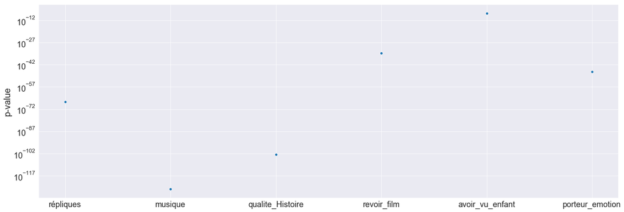

```python
def plot_log(df_chi_deux,testChi2,refut_pvalue=False):
    f, ax = plt.subplots(figsize=(20, 7))
    # Etant donné les valeurs de p-value obtenue il faut une échelle logarithmique
    ax.set(yscale="log")
    # J'ai ajouté un élément inutile pour redécaler les légendes vers la droite
    # (on ne voyait pas répliques et les légendes étaient fausses)
    ax.set_xticklabels([''] + testChi2)
    xaxis = [i for i in range(6)]

    if refut_pvalue == True:
        # Cette option sert à afficher une ligne rouge ou se situe le seuil de 5% pour la p-value
        seuil_cinq_pourcent = [0.05 for i in xaxis]
        plt.plot(xaxis,seuil_cinq_pourcent,'r')
    return sns.scatterplot(x=xaxis, y='p-value', data=df_chi_deux, ax=ax)

plot_log(df_chi_deux,testChi2)
plt.tight_layout()
plt.show()
```

Ce graphique montre la répartition des p-values sur une échelle logarithmique en ordonée. Il est une illustration de ce qu'on a dit plus haut.

### Test du $\chi^2$ sur les deux plus grandes proportions

Nous supposons que les deux populations les plus grandes (regroupant le plus de personnes) sont présente dans les mêmes proportions. Nous allons effectuer un test du $\chi^2$ pour confirmer cette hypothèse ou l'infirmer

```python
dict_snd_chi_deux = {}
for key in testChi2:
    value = []

    # On stocke le maximum de cette colonne
    list_inter = list(df_stat[key])
    maxi = max(list_inter)
    value.append(maxi)

    # On stocke le maximum de cette colonne après avoir supprimé le précédent maximum
    list_inter.remove(maxi)
    maxi = max(list_inter)
    value.append(maxi)

    dict_snd_chi_deux[key] = value

# On crée le data frame
df_inter_chi_deux = pd.DataFrame(dict_snd_chi_deux)
dict_plot_snd_chi_deux = test_stat_chi_deux(testChi2,df_inter_chi_deux)

df_plot_snd_chi_deux = pd.DataFrame(dict_plot_snd_chi_deux)
df_plot_snd_chi_deux.set_axis(['p-value'], axis = 1, inplace= True)
```

```
Résultat du test du chi deux pour la caractéristique répliques

statistic =  34.45816733067729
p-value =  4.35511478276811e-09

Résultat du test du chi deux pour la caractéristique musique

statistic =  93.88339222614842
p-value =  3.3467043489786993e-22

Résultat du test du chi deux pour la caractéristique qualite_Histoire

statistic =  68.75091575091575
p-value =  1.1171897958417422e-16

Résultat du test du chi deux pour la caractéristique revoir_film

statistic =  4.883408071748879
p-value =  0.02711602906411855

Résultat du test du chi deux pour la caractéristique avoir_vu_enfant

statistic =  7.225
p-value =  0.00718951725016505

Résultat du test du chi deux pour la caractéristique porteur_emotion

statistic =  0.49794238683127573
p-value =  0.48040561742029564
```

[figure not shown]

```python
ax = plot_log(df_plot_snd_chi_deux,testChi2,True)
ax.legend(labels = ["p-value catégorie","pvalue = 0.05"])
plt.show()
```

Ici nous pouvons remarquer que toute les tests révèlent une p-value <0.05 , excepté la p-value du "porteur d'émotion", qui elle est clairement au dessus (p-value = 0.48) du seuil. Nous pouvons donc affirmer :

- Les répliques sont importantes pour qu'un film soit mémorable (D'accord)
- La musique est importante pour qu'un film soit mémorable (D'accord)
- La qualité de l'histoire est importante pour qu'un film soit mémorable
- Revoir un film est important pour qu'un film soit mémorable
- Avoir vu un film enfant est important pour qu'un film soit mémorable
- L'hypothèse nulle est acceptée pour la caractéristique porteur d'émotion. On peut conclure que nous n'avons pas assez d'élément pour déterminer si oui ou non cette caractéristique est importante pour qu'un film soit mémorable

## Hypothèse 9

Les étudiants de l’IMT reconnaissent plus facilement les films proposés

- $H_0:\mu_{IMT}=\mu_{nonIMT}$
- $H_a:\mu_{IMT}\neq\mu_{nonIMT}$

### Visualisation des données

```python
def répliques(colonne, critère, nomCritère1, nomCritère2,title):
    répliques=pd.DataFrame(index=[nomCritère1,nomCritère2])

    répliques['Star Wars']=[dataset[dataset[colonne]==critère]['sw_rep_1'].value_counts()['Yes']/len(dataset[dataset[colonne]==critère]['sw_rep_1']),dataset[dataset[colonne]!=critère]['sw_rep_1'].value_counts()['Yes']/len(dataset[dataset[colonne]!=critère]['sw_rep_1'])]
    répliques['Titanic']=[dataset[dataset[colonne]==critère]['tit_rep_1'].value_counts()['Yes']/len(dataset[dataset[colonne]==critère]['tit_rep_1']),dataset[dataset[colonne]!=critère]['tit_rep_1'].value_counts()['Yes']/len(dataset[dataset[colonne]!=critère]['tit_rep_1'])]
    répliques['Terminator']=[dataset[dataset[colonne]==critère]['ter_rep_1'].value_counts()['Yes']/len(dataset[dataset[colonne]==critère]['ter_rep_1']),dataset[dataset[colonne]!=critère]['ter_rep_1'].value_counts()['Yes']/len(dataset[dataset[colonne]!=critère]['ter_rep_1'])]
    répliques['LotR']=[dataset[dataset[colonne]==critère]['lotr_rep_1'].value_counts()['Yes']/len(dataset[dataset[colonne]==critère]['lotr_rep_1']),dataset[dataset[colonne]!=critère]['lotr_rep_1'].value_counts()['Yes']/len(dataset[dataset[colonne]!=critère]['lotr_rep_1'])]
    répliques['Roi Lion']=[dataset[dataset[colonne]==critère]['rl_rep_1'].value_counts()['Yes']/len(dataset[dataset[colonne]==critère]['rl_rep_1']),dataset[dataset[colonne]!=critère]['rl_rep_1'].value_counts()['Yes']/len(dataset[dataset[colonne]!=critère]['rl_rep_1'])]

    fig=répliques.iplot(kind='bar',asFigure= True,title=title)

    fig.layout.yaxis.tickformat = ".2%"

    fig.iplot()


def musiques(colonne, critère, nomCritère1, nomCritère2,title):
    musiques=pd.DataFrame(index=[nomCritère1,nomCritère2])

    musiques['Star Wars']=[dataset[dataset[colonne]==critère]['sw_mus_1'].value_counts()['Yes']/len(dataset[dataset[colonne]==critère]['sw_mus_1']),dataset[dataset[colonne]!=critère]['sw_mus_1'].value_counts()['Yes']/len(dataset[dataset[colonne]!=critère]['sw_mus_1'])]
    musiques['Titanic']=[dataset[dataset[colonne]==critère]['tit_mus_1'].value_counts()['Yes']/len(dataset[dataset[colonne]==critère]['tit_mus_1']),dataset[dataset[colonne]!=critère]['tit_mus_1'].value_counts()['Yes']/len(dataset[dataset[colonne]!=critère]['tit_mus_1'])]
    musiques['Terminator']=[dataset[dataset[colonne]==critère]['ter_mus_1'].value_counts()['Yes']/len(dataset[dataset[colonne]==critère]['ter_mus_1']),dataset[dataset[colonne]!=critère]['ter_mus_1'].value_counts()['Yes']/len(dataset[dataset[colonne]!=critère]['ter_mus_1'])]
    musiques['LotR']=[dataset[dataset[colonne]==critère]['lotr_mus_1'].value_counts()['Yes']/len(dataset[dataset[colonne]==critère]['lotr_mus_1']),dataset[dataset[colonne]!=critère]['lotr_mus_1'].value_counts()['Yes']/len(dataset[dataset[colonne]!=critère]['lotr_mus_1'])]
    musiques['Roi Lion']=[dataset[dataset[colonne]==critère]['rl_mus_1'].value_counts()['Yes']/len(dataset[dataset[colonne]==critère]['rl_mus_1']),dataset[dataset[colonne]!=critère]['rl_mus_1'].value_counts()['Yes']/len(dataset[dataset[colonne]!=critère]['rl_mus_1'])]

    fig=musiques.iplot(kind='bar',asFigure= True,title=title)

    fig.layout.yaxis.tickformat = ".2%"

    fig.iplot()
```

```python
répliques('etudiant_IMT','Oui','étudiant','pas étudiant','Répliques reconnues en fonction du statut (étudiant ou non)')
```

[interactive chart not shown]

```python
musiques('etudiant_IMT','Oui','étudiant','pas étudiant','Musiques reconnues en fonction du statut (étudiant ou non)')
```

[interactive chart not shown]

### Application du test

```python
mean_student_serie(
    dataset[dataset['etudiant_IMT']=='Oui']["per_total"],
    "connaissance des films pour les étudiants IMT",
    dataset[dataset['etudiant_IMT']=='Non']["per_total"],
    "connaissance des films pour les non-étudiants IMT"
)
```

```
La moyenne de connaissance des films pour les étudiants IMT est de 0.75 et la moyenne de connaissance des films pour les non-étudiants IMT est de 0.7
```

```python
student_pval_serie_ind(
    dataset[dataset['etudiant_IMT']=='Oui']["per_total"],
    dataset[dataset['etudiant_IMT']=='Non']["per_total"]
)
```

```
pvalue = 0.04971413821684558, t = 1.970433896213916
L'intervalle de confiance des différence de moyenne est de : [-0.1,0.00].
```

```python
print("Le nombre de personne non IMT Atlantique ayant répondu au sondage : {} et le nombre d'étudiant IMT Atlantique {}"
      .format(len(dataset[dataset["etudiant_IMT"]=="Non"]),len(dataset[dataset["etudiant_IMT"]=="Oui"])))
```

```
Le nombre de personne non IMT Atlantique ayant répondu au sondage : 136 et le nombre d'étudiant IMT Atlantique 164
```

On remarque que l'hypothèse à une p-value inférieur à 0.05. Nous pouvons donc rejeter l'hypothèse nulle. Ainsi les étudiant d'IMT Atlantique ont plus tendance à reconnaître les films comparés aux personnes non-étudiant à IMT Atlantique. Cela est une des hypothèses que l'ont souhaitait validé.  
En effet lors de la sélection des films, nous avions pensé qu'étant tous issu d'un milieu assez homogène, ce que nous avons pensé être connu l'est aussi pour les étudiant d'IMT Atlantique, mais peut être pas pour les autres. Ce test vient de le confirmer.

## Femme IMT et non IMT

```python
col_to_plot = ["per_total"]
df_plot = pd.DataFrame()
norm = dataset[(dataset["etudiant_IMT"] == "Oui") & (dataset["sexe"] == "Femme")]["per_total"].count()
for k in col_to_plot:
    df_plot[k+"IMT"] = dataset[(dataset["etudiant_IMT"] == "Oui") & (dataset["sexe"] == "Femme")][k].value_counts()/norm
norm = dataset[(dataset["etudiant_IMT"] == "Non") & (dataset["sexe"] == "Femme")]["per_total"].count()
for k in col_to_plot:
    df_plot[k+"nonIMT"] = dataset[(dataset["etudiant_IMT"] == "Non") & (dataset["sexe"] == "Femme")][k].value_counts()/norm

df_plot = df_plot.sort_index(ascending = False).transpose()
```

```python
fig = df_plot.loc[:,].iplot(kind = "bar",asFigure= True, title = "Score au blind test selon la population concernée")
labels = ["Score au blindtest : {}/10".format(i) for i in range(10,-1,-1)]
lab_x_axis = np.array(["Etudiantes IMT","Non Etudiantes IMT"])
cpt =0
for k in fig.data:
    k.name = labels[cpt]
    k.x = lab_x_axis
    cpt+=1
fig.layout.yaxis.tickformat = ".2%"
fig.layout.yaxis.title = "Pourcentage de la population concernée"
fig.iplot()
```

[interactive chart not shown]

# Commentaires

- 3 pays inconnus : Austr et Unite et Yougoslavie, pourrait être Austria/Australia, USA/UK/EAU et Serbie/Monténégro
- Certaines personnes prouvent par leur réponse qu'ils connaissent le film, mais ne se rappellent plus du nom. On considère ces réponses bonnes.